# Numpy basics

###### Apr 14, 2020 in Python

Numpy arrays are used for manipulation of data. Some of the common operations that can be done by the numpy arrays are - split, reshape and join the arrays.

The types of operations shown below may be dry as we don't get to see the use cases immediately, the below operations forms as the building blocks for real use-case scenarios when we encounter them.

#### Importing Numpy

```
# importing numpy with a common alias np

import numpy as np
```

#### Getting the numpy version

```
# numpy version
# The double underscore is referred to as dunder

print(np.__version__)
```

```
1.18.1
```

#### Defining a numpy array

```
# defining a numpy array

arr = np.array([1,2,58])
```

```
# Getting the type of the array

type(arr)
```

```
numpy.ndarray
```

This shows that it's an 'n' dimension array. Let's check how many dimension it has - using the `ndim` function

```
# Getting the number of dimensions of an array

arr.ndim
```

```
1
```

The above array 'arr' has got only one dimensions as it has just one row

#### Let's define a few arrays - one dimension, two dimension, three dimension arrays

The `random` module in numpy is used to generate a sequence of random numbres. We will use the `random` module to generate the arrays

```
# use a seed value for reproducibility

np.random.seed(0)
```

```
# Generate 6 values within the range of 0 to 10

x1 = np.random.randint(10, size=6) # one-dimension array
print(x1)
```

```
[8 8 1 6 7 7]
```

```
# Generate an array of size - 3 rows and 4 columns
# with a range of values 0 to 10

x2 = np.random.randint(10, size=(3,4)) # two-dimension array
print(x2)
```

```
[[8 1 5 9]
 [8 9 4 3]
 [0 3 5 0]]
```

```
# Generate an array of size - 3 elements of size 4 rows and 5 column arrays

x3 = np.random.randint(10, size=(3,4,5)) # three dimension array
print(x3)
```

```
[[[5 9 3 0 5]
  [0 1 2 4 2]
  [0 3 2 0 7]
  [5 9 0 2 7]]

 [[2 9 2 3 3]
  [2 3 4 1 2]
  [9 1 4 6 8]
  [2 3 0 0 6]]

 [[0 6 3 3 8]
  [8 8 2 3 2]
  [0 8 8 3 8]
  [2 8 4 3 0]]]
```

#### Array attributes

Each array has attributes `ndim` (the number of dimensions), `shape` (the size of each dimension), and `size` (the total size of the array):

```
# attributes of the one dimension array

print("x1 ndim: ", x1.ndim)
print("x1 shape:", x1.shape)
print("x1 size: ", x1.size)
```

```
x1 ndim:  1
x1 shape: (6,)
x1 size:  6
```

```
# attributes of the two dimension array

print("x2 ndim: ", x2.ndim)
print("x2 shape:", x2.shape)
print("x2 size: ", x2.size)
```

```
x2 ndim:  2
x2 shape: (3, 4)
x2 size:  12
```

```
# attributes of the three dimension array

print("x3 ndim: ", x3.ndim)
print("x3 shape:", x3.shape)
print("x3 size: ", x3.size)
```

```
x3 ndim:  3
x3 shape: (3, 4, 5)
x3 size:  60
```

Another useful attribute is the `dtype`, the data type of the array

```
# Getting the type of the array

print('dtype:', x3.dtype)
```

```
dtype: int32
```

Other attributes include `itemsize`, which lists the size (in bytes) of each array element, and `nbytes`, which lists the total size (in bytes) of the array:

```
# getting the itemsize and the number of bytes of the array

print("itemsize:", x3.itemsize, "bytes")
print("nbytes:", x3.nbytes, "bytes")
```

```
itemsize: 4 bytes
nbytes: 240 bytes
```

In general, we expect that `nbytes` is equal to `itemsize` times `size`.

### Array Indexing: Accessing single elements

```
# Get the value of the x1 array

x1
```

```
array([8, 8, 1, 6, 7, 7])
```

```
# Access the first element

x1[0]
```

```
8
```

```
# Access the last element

x1[-1]
```

```
7
```

In a multi-dimensional array, items can be accessed using a comma-separated tuple of indices:

```
# Get the value of x2

x2
```

```
array([[8, 1, 5, 9],
       [8, 9, 4, 3],
       [0, 3, 5, 0]])
```

```
# Access the first row, first element

x2[0,0]
```

```
8
```

```
# Access the second row, third element

x2[1,2]
```

```
4
```

```
# Access the last row, last before element

x2[2,-2]
```

```
5
```

Values can also be modified using any of the above index notation

```
# Let's change the first row, first element to 12

# printing the previous x2

print(x2)

# change the first row, first element to 12
x2[0, 0] = 12

# Get the new x2

print("---")
print(x2)
```

```
[[8 1 5 9]
 [8 9 4 3]
 [0 3 5 0]]
---
[[12  1  5  9]
 [ 8  9  4  3]
 [ 0  3  5  0]]
```

Keep in mind that, unlike Python lists, NumPy arrays have a fixed type. This means, for example, that if you attempt to insert a floating-point value to an integer array, the value will be silently truncated. Don't be caught unaware by this behavior!

```
# Lets change the first row, first element to
# a floating point number e.g. 3.1415

# print old x2
print(x2)

# Assign a floating point number to the first element
# This will be truncated

x2[0,0] = 3.1415

print("---")

# print new x2
print(x2)
```

[output not shown]

You can see that thought we have assigned the number as `3.1415`, it has been truncated to `3` as the array `x2` is of integer type and hence cannot take floating point numbers.

### Array Slicing: Accessing Subarrays

Just as we can use square brackets to access individual array elements, we can also use them to access subarrays with the slice notation, marked by the colon (`:`) character. The NumPy slicing syntax follows that of the standard Python list; to access a slice of an array `x`, use this:

`x[start:stop:step]`

If any of these are unspecified, they default to the values `start=0`, `stop=size of dimension`, `step=1`. We'll take a look at accessing sub-arrays in one dimension and in multiple dimensions.

```
# Let's define an one dimension array

x = np.arange(10)
print(x)
```

```
[0 1 2 3 4 5 6 7 8 9]
```

```
# Get the first five elements

x[:5]
```

```
array([0, 1, 2, 3, 4])
```

```
# elements after index 5

x[5:]
```

```
array([5, 6, 7, 8, 9])
```

```
# slicing from the middle

x[4:7]
```

```
array([4, 5, 6])
```

```
# Every second element

x[::2]
```

```
array([0, 2, 4, 6, 8])
```

```
# Every second element starting from 1

x[1::2]
```

```
array([1, 3, 5, 7, 9])
```

A potentially confusing case is when the `step` value is negative. In this case, the defaults for `start` and `stop` are swapped. This becomes a convenient way to reverse an array:

```
# reversing the entire array

x[::-1]
```

```
array([9, 8, 7, 6, 5, 4, 3, 2, 1, 0])
```

```
# reversing every other element from index 5
# remember to sway the start and stop position

x[5::-2]
```

```
array([5, 3, 1])
```

### Multi-Dimension Subarrays

Multi-dimensional slices work in the same way, with multiple slices separated by commas.

```
# Let's get x2 we defined earlier

x2
```

```
array([[3, 1, 5, 9],
       [8, 9, 4, 3],
       [0, 3, 5, 0]])
```

```
# Getting the first two rows and three columns

x2[:2,:3]
```

```
array([[3, 1, 5],
       [8, 9, 4]])
```

```
# Getting all rows and every other column

x2[:,::2]
```

```
array([[3, 5],
       [8, 4],
       [0, 5]])
```

Since the range is for all rows, we don't give the start and the stop range.

For columns, since we need every other column in the range, we dont specify the start and the stop range but just the step

Subarray dimensions can be reversed as well.

```
# Printing original array

x2
```

```
array([[3, 1, 5, 9],
       [8, 9, 4, 3],
       [0, 3, 5, 0]])
```

```
# reverse the array

x2[::-1, ::-1]
```

```
array([[0, 5, 3, 0],
       [3, 4, 9, 8],
       [9, 5, 1, 3]])
```

### Accessing array rows and columns

One commonly needed routine is accessing of single rows or columns of an array. This can be done by combining indexing and slicing, using an empty slice marked by a single colon (`:`):

```
# Get the x2 array

x2
```

```
array([[3, 1, 5, 9],
       [8, 9, 4, 3],
       [0, 3, 5, 0]])
```

```
# Get the first column of x2

x2[:,0]
```

```
array([3, 8, 0])
```

```
# get the first row of x2

x2[0,:]
```

```
array([3, 1, 5, 9])
```

In case of row access, the empty slice can be omitted for a more compact syntax

```
# equivalent to x2[0, :]

print(x2[0])
```

```
[3 1 5 9]
```

### Subarrays as no-copy views

One important and extremely useful thing to know about array slices is that they return views rather than copies of the array data. This is one area in which NumPy array slicing differs from Python list slicing: in lists, slices will be copies. Consider our two dimensional array from before:

```
# get the x2 array

print(x2)
```

```
[[3 1 5 9]
 [8 9 4 3]
 [0 3 5 0]]
```

```
# Let's extract a 2 x 2 subarray from x2

x2_sub = x2[:2,:2]
print(x2_sub)
```

```
[[3 1]
 [8 9]]
```

Now, if we modify the array, the original array is changed

```
# change the first row, first element to 99

x2_sub[0,0] = 99
print(x2_sub)
```

```
[[99  1]
 [ 8  9]]
```

```
# Get the x2 array

print(x2)
```

```
[[99  1  5  9]
 [ 8  9  4  3]
 [ 0  3  5  0]]
```

This default behavior is actually quite useful: it means that when we work with large datasets, we can access and process pieces of these datasets without the need to copy the underlying data buffer.

### Creating copies of arrays

Despite the nice features of array views, it is sometimes useful to instead explicitly copy the data within an array or a subarray. This can be most easily done with the `copy()` method:

```
# Let's start with the x2 array

print(x2)
```

```
[[99  1  5  9]
 [ 8  9  4  3]
 [ 0  3  5  0]]
```

```
# Let get the first two rows and two columns

x2_sub_arr = x2[:2,:2]
print(x2_sub_arr)
```

```
[[99  1]
 [ 8  9]]
```

```
# Let create a copy of this sub array
# use the .copy method

x2_sub_arr_copy = x2_sub_arr.copy()
print(x2_sub_arr_copy)
```

```
[[99  1]
 [ 8  9]]
```

```
# Let change the first row, first element to 0

x2_sub_arr_copy[0,0] = 0
print(x2_sub_arr_copy)
```

```
[[0 1]
 [8 9]]
```

```
# Let's print the original x2

print(x2)
```

```
[[99  1  5  9]
 [ 8  9  4  3]
 [ 0  3  5  0]]
```

As you can see, the original `x2` array still has the number 99 as the first element as the original array `x2` is not touched.

### Reshaping for arrays

Another useful type of operation is reshaping of arrays. The most flexible way of doing this is with the `reshape` method. For example, if you want to put the numbers 1 through 9 in a 3 x 3 grid, you can do the following:

```
# Let's form a grid of 9 elements

grid = np.arange(1, 10)
print(grid)
```

```
[1 2 3 4 5 6 7 8 9]
```

```
# Let's reshape this to a 3 x 3 grid

grid.reshape(3,3)
```

```
array([[1, 2, 3],
       [4, 5, 6],
       [7, 8, 9]])
```

Note that for this to work, the size of the initial array must match the size of the reshaped array.

We can also reshape a one-dimension array

```
# Let's declare a one-dimension array

x = np.array([1,2,3])
```

```
# Let's re-shape this to a 1,3 array
# i.e. 1 row, 3 columns array

x.reshape(1,3)
print(x)
```

```
[1 2 3]
```

```
# Let's re-shape x to a 3,1 array
# i.e. 3 rows and 1 column array

x.reshape(3,1)
```

```
array([[1],
       [2],
       [3]])
```

```
# The other way of doing this
# is by using .newaxis method

x[:, np.newaxis]
```

```
array([[1],
       [2],
       [3]])
```

```
# To change back to 1 row, 3 columns

x[np.newaxis, :]
```

```
array([[1, 2, 3]])
```

### Array concatenation

All of the preceding routines worked on single arrays. It's also possible to combine multiple arrays into one, and to conversely split a single array into multiple arrays.

Concatenation, or joining of two arrays in NumPy, is primarily accomplished using the routines `np.concatenate`, `np.vstack`, and `np.hstack`

```
# np.concatenate

x = np.array([1,2,3])
y = np.array([4,5,6])

np.concatenate([x,y]) # Note the arrays are within [ ]
```

```
array([1, 2, 3, 4, 5, 6])
```

```
# More than two arrays can also be concatenated

z = [99, 99, 99]

np.concatenate([x,y,z])
```

```
array([ 1,  2,  3,  4,  5,  6, 99, 99, 99])
```

```
# Concatenating two-dimension arrays

grid = np.array([[1,2,3],[4,5,6]])

# concatenating along the first axis i.e. columns

np.concatenate([grid, grid])
```

```
array([[1, 2, 3],
       [4, 5, 6],
       [1, 2, 3],
       [4, 5, 6]])
```

```
# concatenating along the second axis i.e rows

np.concatenate([grid, grid], axis=1)
```

```
array([[1, 2, 3, 1, 2, 3],
       [4, 5, 6, 4, 5, 6]])
```

**For working with arrays of mixed dimensions**, it can be clearer to use the `np.vstack` (vertical stack) and `np.hstack` (horizontal stack) functions:

```
# lets define a single dimension array

x = np.array([1,2,3])

# let's define a two dimension array

grid = np.array([[1,2,3],[4,5,6]])

print(x)
print(grid)
```

```
[1 2 3]
[[1 2 3]
 [4 5 6]]
```

```
# let's vertically stack the arrays
# use the vstack method

np.vstack([x, grid])
```

```
array([[1, 2, 3],
       [1, 2, 3],
       [4, 5, 6]])
```

```
# let's stack the arrays horizontally
# use the hstack method

y = np.array([[99],
             [99]])

np.hstack([grid, y])
```

```
array([[ 1,  2,  3, 99],
       [ 4,  5,  6, 99]])
```

### Array Splitting

The opposite of concatenation is splitting, which is implemented by the functions `np.split`, `np.hsplit`, and `np.vsplit`

```
# Let's define a array

x = [1,2,3,99,99,3,2,1]

# split from index 3 to 5
# this would give three sub arrays
# [1,2,3] - [99,99] - [3,2,1]

# Get these 3 sub arrays in 3 variables

x_1, x_2, x_3 = np.split(x, [3,5])
print(x_1, x_2, x_3)
```

```
[1 2 3] [99 99] [3 2 1]
```

```
# vertically splitting an array

# Let's make a multi-dim array

grid = np.arange(16).reshape(4,4)
print(grid)
```

```
[[ 0  1  2  3]
 [ 4  5  6  7]
 [ 8  9 10 11]
 [12 13 14 15]]
```

```
# use the vsplit method to split the array
# vertically

upper, lower = np.vsplit(grid, [2])
print(upper)
print(lower)
```

```
[[0 1 2 3]
 [4 5 6 7]]
[[ 8  9 10 11]
 [12 13 14 15]]
```

```
# use the hsplit method to split
# the array horizontally

left, right = np.hsplit(grid, [2])
print(left)
print(right)
```

```
[[ 0  1]
 [ 4  5]
 [ 8  9]
 [12 13]]
[[ 2  3]
 [ 6  7]
 [10 11]
 [14 15]]
```

### Iterating thru arrays

```
# Let get the array x
# and iterate thru it

print(x)

# 1D array
for i in x:
    print(i)
```

```
[1, 2, 3, 99, 99, 3, 2, 1]
1
2
3
99
99
3
2
1
```

```
# Lets get the 2d array x2
# and iterate thru it

print(x2)

for i in x2:
    for j in i:
        print(j)
```

```
[[99  1  5  9]
 [ 8  9  4  3]
 [ 0  3  5  0]]
99
1
5
9
8
9
4
3
0
3
5
0
```

```
# Let's get the 3d array x3
# and iterate thru it

print(x3)

print("---")

for i in x3:
    for j in i:
        print(j)
        # for k in j: print(k)
```

```
[[[5 9 3 0 5]
  [0 1 2 4 2]
  [0 3 2 0 7]
  [5 9 0 2 7]]

 [[2 9 2 3 3]
  [2 3 4 1 2]
  [9 1 4 6 8]
  [2 3 0 0 6]]

 [[0 6 3 3 8]
  [8 8 2 3 2]
  [0 8 8 3 8]
  [2 8 4 3 0]]]
---
[5 9 3 0 5]
[0 1 2 4 2]
[0 3 2 0 7]
[5 9 0 2 7]
[2 9 2 3 3]
[2 3 4 1 2]
[9 1 4 6 8]
[2 3 0 0 6]
[0 6 3 3 8]
[8 8 2 3 2]
[0 8 8 3 8]
[2 8 4 3 0]
```

### Addition, subtraction, multiplication in a numpy array

```
# Let's define the first array
# of 16 elements

arr1 = np.array(range(1,17,1))
print(arr1)
```

```
[ 1  2  3  4  5  6  7  8  9 10 11 12 13 14 15 16]
```

```
# Let's reshape it to a 4 x 4 matrix

arr1 = arr1.reshape(4,4)
print(arr1)
```

```
[[ 1  2  3  4]
 [ 5  6  7  8]
 [ 9 10 11 12]
 [13 14 15 16]]
```

```
# Let's define the second array
# of 16 elements with difference 10

arr2 = np.array(range(10,170,10))
print(arr2)
```

```
[ 10  20  30  40  50  60  70  80  90 100 110 120 130 140 150 160]
```

```
# Let's reshape it to a 4 x 4 matrix

arr2 = arr2.reshape(4,4)
print(arr2)
```

```
[[ 10  20  30  40]
 [ 50  60  70  80]
 [ 90 100 110 120]
 [130 140 150 160]]
```

```
# addition of two arrays

arr1 + arr2
```

```
array([[ 11,  22,  33,  44],
       [ 55,  66,  77,  88],
       [ 99, 110, 121, 132],
       [143, 154, 165, 176]])
```

```
#  subtracting two arrays

arr2 - arr1
```

```
array([[  9,  18,  27,  36],
       [ 45,  54,  63,  72],
       [ 81,  90,  99, 108],
       [117, 126, 135, 144]])
```

```
# Multiplying two arrays

arr1 * arr2
```

```
array([[  10,   40,   90,  160],
       [ 250,  360,  490,  640],
       [ 810, 1000, 1210, 1440],
       [1690, 1960, 2250, 2560]])
```

```
# Dividing the arrays

arr2 / arr1
```

```
array([[10., 10., 10., 10.],
       [10., 10., 10., 10.],
       [10., 10., 10., 10.],
       [10., 10., 10., 10.]])
```

```
# array multiplication with a scalar value
# e.g arr1 * 10

arr1 * 10
```

```
array([[ 10,  20,  30,  40],
       [ 50,  60,  70,  80],
       [ 90, 100, 110, 120],
       [130, 140, 150, 160]])
```

```
# dot product
# dot product is different from multiplication

np.dot(arr1, arr2)
```

```
array([[ 900, 1000, 1100, 1200],
       [2020, 2280, 2540, 2800],
       [3140, 3560, 3980, 4400],
       [4260, 4840, 5420, 6000]])
```

### Sorting and searching

```
# Let's define an array

print(x)
```

```
[1, 2, 3, 99, 99, 3, 2, 1]
```

```
# sorting 1D array

np.sort(x)
```

```
array([ 1,  1,  2,  2,  3,  3, 99, 99])
```

```
# Lets get a 2d array

print(x2)
```

```
[[99  1  5  9]
 [ 8  9  4  3]
 [ 0  3  5  0]]
```

```
# sorting a 2d array
# will sort elements in each rows

np.sort(x2)
```

```
array([[ 1,  5,  9, 99],
       [ 3,  4,  8,  9],
       [ 0,  0,  3,  5]])
```

### Statistics with numpy

```
# Let's define an array

stat_arr = np.arange(1,10)
print(stat_arr)
```

```
[1 2 3 4 5 6 7 8 9]
```

```
# Get the mean of the array

np.mean(stat_arr)
```

```
5.0
```

```
# Get the median of the array

np.median(stat_arr)
```

```
5.0
```

```
# get the std dev of the array

np.std(stat_arr)
```

```
2.581988897471611
```

```
# get the variance

np.var(stat_arr)
```

```
6.666666666666667
```

```
# get the percentile

scores = [80,90,70,85,60,55,75,89,12,13,15]
np.percentile(scores,80)
```

```
85.0
```

```
# mean of a 2d array

print(x2)

# getting the mean across rows
# axis = 1

np.mean(x2, axis=1)
```

```
[[99  1  5  9]
 [ 8  9  4  3]
 [ 0  3  5  0]]
```

```
array([28.5,  6. ,  2. ])
```

```
# getting the mean across columns

np.mean(x2, axis=0)
```

```
array([35.66666667,  4.33333333,  4.66666667,  4.        ])
```

```
# Drawing an histogram

import matplotlib.pyplot as plt
norm_data = np.random.normal(10,1.0,5000000)
plt.hist(norm_data, 200) # 200 is the number of bins
plt.show()
```

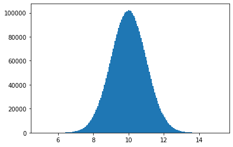

```
# Getting a random integer
# in a range

np.random.randint(1,100)
```

```
91
```

```
# generating a random number
# first param : range
# second param : size

np.random.rand(1,100)
```

```
array([[0.47390871, 0.9424515 , 0.08067525, 0.50477582, 0.75355236,
        0.6443007 , 0.68009591, 0.85948974, 0.79562236, 0.67030161,
        0.21086869, 0.43761942, 0.14953803, 0.73310741, 0.0978983 ,
        0.78410335, 0.74009511, 0.23071498, 0.13325923, 0.19633374,
        0.68353164, 0.23094352, 0.17681563, 0.14249063, 0.51898069,
        0.21801461, 0.0914506 , 0.28495553, 0.09474098, 0.55464705,
        0.94250659, 0.24068165, 0.80642805, 0.34753732, 0.16368083,
        0.49636519, 0.22354509, 0.76651945, 0.03019415, 0.64006132,
        0.035494  , 0.21898449, 0.51010665, 0.41423507, 0.91151493,
        0.6051262 , 0.77595892, 0.43230851, 0.77152591, 0.85263481,
        0.16105187, 0.06416947, 0.41576968, 0.28921585, 0.03823162,
        0.11454612, 0.45932632, 0.78403473, 0.40116525, 0.94245161,
        0.98495574, 0.40247529, 0.76547687, 0.76620485, 0.3622606 ,
        0.66219648, 0.0360825 , 0.23129832, 0.77402102, 0.23150597,
        0.66776317, 0.15584173, 0.64016945, 0.69802422, 0.55093934,
        0.80262937, 0.59689222, 0.55314997, 0.19660366, 0.25421008,
        0.67910571, 0.75892023, 0.15447376, 0.52093862, 0.37407023,
        0.88858665, 0.10001336, 0.63902172, 0.71561141, 0.44134696,
        0.77242583, 0.08833249, 0.61827113, 0.22744314, 0.77190824,
        0.78893133, 0.34247442, 0.35901415, 0.68427893, 0.2549437 ]])
```

```
# getting a choice in a given range
# random.choice takes two parameters
# first param: list of numbers
# second param: size in rows and columns

np.random.choice([1,3,5,7,10], size=(1,3))
```

```
array([[ 7, 10, 10]])
```

```
#  plotting a chi-square graph

import matplotlib.pyplot as plt
import seaborn as sns

chi = np.random.chisquare(df = 1, size = 100000)
sns.distplot(chi, hist = False)
plt.show()
```

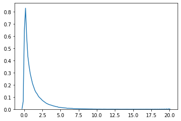

### Functions involved in generating array

```
# Let's create an array and reshape it

a = np.arange(1,17).reshape(4,4)
```

```
print(a)
```

```
[[ 1  2  3  4]
 [ 5  6  7  8]
 [ 9 10 11 12]
 [13 14 15 16]]
```

```
# linspace : uniformly spaced elements

np.linspace(0,100,5)
```

```
array([  0.,  25.,  50.,  75., 100.])
```

```
# arange: generates values based on the step

np.arange(0,100,5)
```

```
array([ 0,  5, 10, 15, 20, 25, 30, 35, 40, 45, 50, 55, 60, 65, 70, 75, 80,
       85, 90, 95])
```

```
# Zero: fills the shape specified in the param as zeros

np.zeros((3,3))
```

```
array([[0., 0., 0.],
       [0., 0., 0.],
       [0., 0., 0.]])
```

```
# Ones - fills the shapes as ones

np.ones((3,3))
```

```
array([[1., 1., 1.],
       [1., 1., 1.],
       [1., 1., 1.]])
```

```
# Identity matrix: ones in the diagonal

np.eye(3)
```

```
array([[1., 0., 0.],
       [0., 1., 0.],
       [0., 0., 1.]])
```

```
# Diagonal matrix: only the diagonal has numbers

np.diag([1,2,3,4,5])
```

```
array([[1, 0, 0, 0, 0],
       [0, 2, 0, 0, 0],
       [0, 0, 3, 0, 0],
       [0, 0, 0, 4, 0],
       [0, 0, 0, 0, 5]])
```

```
# can we reshape a string array?

arr = np.array([1,2,3,"Inceptz"])
arr.reshape(2,2)
```

```
array([['1', '2'],
       ['3', 'Inceptz']], dtype='<U11')
```